# Instrumental Variables

Rachel Childers

```r
library(foreign)
library(AER)
library(npcausal)
library(stargazer)
```

## Instrumental Variables: Setting

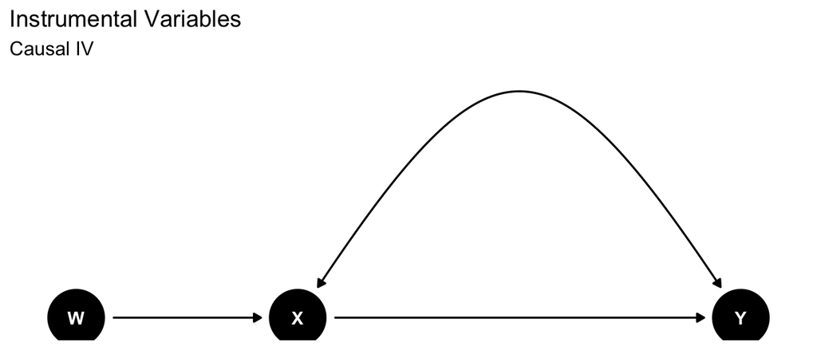

```r
library(dagitty)
library(ggdag)
ivgraph<-dagitty("dag{Y<-X; X<-W; X<->Y}") #create graph
#Set position of nodes
  coords<-list(x=c(X = 0, Y = 2, W=-1),y=c(X = 0, Y = 0, W=0))
  coords_df<-coords2df(coords)
  coordinates(ivgraph)<-coords2list(coords_df)
ggdag(ivgraph)+theme_dag_blank()+ggplot2::labs(title="Instrumental Variables",subtitle="Causal IV") #Plot causal graph
```

- Goal remains recovering the effect of $X$ on $Y$
  - Assume above causal graph, in NPSEM-IE model
- In most non-experimental settings, can’t rule out presence of unobserved confounding
- In some of these cases, we have a variable $W$ which is effectively random, but it’s not the treatment we care about
  - A natural experiment, or, most credibly, an *actual* experiment
  - Reflected by absence of incoming arrows into $W$
- Problem that comes up in actual experiments, especially with humans involved: *imperfect compliance*
  - If you try to make people do $X$, some of them still won’t do $X$
- We can measure the effect of $W$ on $X$: the *first stage*
  - Amount by which changing $W$ changes actual decision to do $X$
  - In experiment, this is rate of compliance with assignment
- We can measure effect of $W$ on $Y$: the *reduced form* or *intent to treat* (ITT) effect
- If assignment $W$ does not directly affect the outcome, this is only coming from induced variation in $X$
  - Lack of direct arrow from $W$ to $Y$ is called *exclusion*
- Can we somehow use these to measure the effect of $X$ on $Y$?
  - Sometimes!
  - But only under some more assumptions

## “Classical IV” (Wright (1928))

- Assume linear structural causal model (demeaned for simplicity)
  - $Y=\beta X+U$, $X=\gamma W+E$
- Due to omitted confounders, $Cov(U,X)\neq 0$ “*endogeneity*”
  - $Y$ and $X$ equations are *not* full structural equations, as $U$ and $E$ contain shared omitted variable
  - But $\beta$ and $\gamma$ *are* structural coefficients, and $W$ is uncorrelated with the omitted variable
- By linearity, effect of $W$ on $Y$ is $\rho=\beta\cdot\gamma$
- If $\gamma\neq0$ (“relevance”), $\beta=\frac{\rho}{\gamma}$
  - Estimate by $\frac{\widehat{\rho}}{\widehat{\gamma}}$ ratio of regressions of $Y$ on $W$, $X$ on $W$
- This is IV every economist knows
  - Note “endogeneity” as correlation of regressors with errors meaningful only in context of structural equations
- Extensions to multiple IVs, added controls, via 2SLS
- Problem: linearity here is not just a convenient calculating device
  - Implies *homogeneity*: causal effects the same for all units
  - Relevance is *added* condition beyond implications of structure of graph
  - Means that IV estimand not derivable from do-calculus methods alone
- How do we generalize to less restrictive models?
  - Opens up a cornucopia (or Pandora’s box) of different IV extensions

## Binary Instrument, Binary Treatment

- Let $(Y_i,X_i,W_i)\in\mathbb{R}\times\{0,1\}\times\{0,1\}$ be our outcome, treatment of interest, and instrumental variable
- Goal is to measure effect of $X$, but it may not be randomly assigned
- Instead, we have instrument $W_i$ which is randomly assigned, so we can measure its effect
- Instrumental Variables estimator $\widehat{\beta}^{IV}=\frac{\widehat{Cov}(W_i,Y_i)}{\widehat{Cov}(W_i,X_i)}$
- Can rewrite as ratio of two regressions: $\widehat{\beta}^{IV}=\frac{\widehat{Cov}(W_i,Y_i)/\widehat{Var}(W_i)}{\widehat{Cov}(W,X_i)/\widehat{Var}(W_i)}$
  - *Reduced form*: $\widehat{\rho}=\widehat{Cov}(W_i,Y_i)/\widehat{Var}(W_i)$ regression of $Y$ on $W$
  - *First Stage*: $\widehat{\gamma}=\widehat{Cov}(W_i,X_i)/\widehat{Var}(W_i)$ regression of $X$ on $W$
- Note: *reduced form* has other meanings in SCM context.
- If $Cov(W_i,X_i)\neq 0$, first stage non-zero (a *relevance* condition), $\widehat{\beta}^{IV}$ converges to IV estimand
  - $\beta^{IV}=\frac{E[W_iY_i]-E[W_i]E[Y_i]}{E[W_iX_i]-E[W_i]E[X_i]}$
- In binary $W$ case, can write regressions as differences in means
  - $\rho=E[Y_i|W_i=1]-E[Y_i|W_i=0]$, $\gamma=E[X_i|W_i=1]-E[X_i|W_i=0]$
- Binary instrument case called the *Wald* estimand
  - $\beta^{IV}=\beta^{Wald}=\frac{E[Y_i|W_i=1]-E[Y_i|W_i=0]}{E[X_i|W_i=1]-E[X_i|W_i=0]}$

## LATE Theorem

- Imbens and Angrist (1994) ask when Wald estimator gives meaningful result in potential outcomes model
- Define potential outcomes
  - $X^{W=w}$ describing how treatment responds to instrument
  - $Y^{X=x,W=w}$ how outcome responds to joint setting of instrument and treatment
- Impose usual causal consistency assumptions $X_i=W_iX^1_i+(1-W_i)X^0_i$, $Y_i=\sum_{x,w\in\{0,1\}^2}Y_i^{x,w}1\{X_i=x,W_i=w\}$
- Conditions
  1. Random assignment: $(\{Y_i^{X_i=x,W_i=w}\}_{x,w\in\{0,1\}^2},X_i^1,X_i^0)\perp W_i$
  2. Relevance: $E[X^1_i]-E[X^0_i]\neq 0$
  3. Exclusion: $Y_i^{X_i=x}:=Y_i^{X_i=x,W_i=1}=Y_i^{X_i=x,W_i=0}$, $x\in\{0,1\}$
  4. Monotonicity: $P(X_i^1\geq X_i^0)=1$, (or $P(X_i^1\leq X_i^0)=1$, but use former as sign convention w.l.o.g.)
- **Theorem**: Under (1)-(4), $\beta^{Wald}=E[Y_i^1-Y_i^0|X_i^1=1,X_i^0=0]$
- The quantity $E[Y_i^1-Y_i^0|X_i^1=1,X_i^0=0]$ is called the **Local Average Treatment Effect** or **LATE**
  - It is the causal effect for the subpopulation with $X_i^1=1,X_i^0=0$, the *compliers*
  - Units who are caused to receive the treatment due to having received the instrument

## Interpretation of Conditions

- Note that binary $X$ binary $W$ means responses of $X$ to $W$ can take only 4 possible forms
  - $X_i^{1}=1,X_i^{0}=1$ *Always Takers* who get treatment regardless of instrument
  - $X_i^{1}=1,X_i^{0}=0$ *Compliers* who get treatment iff they get instrument
  - $X_i^{1}=0,X_i^{0}=0$ *Never Takers* who never get treatment regardless of instrument
  - $X_i^{1}=0,X_i^{0}=1$ *Defiers* who get treatment iff they *don’t* get instrument
- Monotonicity assumption says $P(X_i^{1}=0,X_i^{0}=1)=0$: hence also called *No defiers* assumption
  - Claim that direction of effect of $W$ is the same on choice of $X$ for *everyone*
  - Natural when treatment only available in presence of instrument (can’t get drug unless doctor gives it to you)
  - That case gives *one sided noncompliance*: no defiers, also no always takers
- Monotonicity somewhat plausible when instrument is *incentive*: give reward for doing $X$.
  - Works if units universally like or indifferent to reward (money?)
- Monotonicity less plausible in *examiner designs*: randomly assign unit to decision-maker, who then decides to treat or not
  - Doctors/judges often randomly assigned to patients/defendants, but need differences in judgment to always go the same way
- Randomization is sensible when instrument is experiment or natural experiment
- Relevance says that IV changes level of treatment: you can test to see if this is true!
- Exclusion says instrument does not affect outcome except through the treatment
  - Separate from random assignment and not guaranteed! Need a substantive reason why $W->Y$ arrow is missing.
  - Will fail if simply being told you are assigned to treatment changes outcome: e.g. *placebo* effects
- In natural experiments, exclusion requires behavioral invariance to source of random variation
  - Rainfall *might* be random, but is your outcome unaffected by rain?
  - People, especially agricultural workers whose livelihood depends on it, care about the weather!

## Proof

- Claim: $\beta^{Wald}=\frac{E[Y_i|W_i=1]-E[Y_i|W_i=0]}{E[X_i|W_i=1]-E[X_i|W_i=0]}=E[Y_i^1-Y_i^0|X_i^1=1,X_i^0=0]$
- Denominator: $E[X_i|W_i=1]-E[X_i|W_i=0]=E[X_i^1|W_i=1]-E[X_i^0|W_i=0]$ by causal consistency
  - $=E[X_i^1]-E[X_i^0]$ by random assignment
  - $=P(X_i^1=1)-P(X_i^0=1)\neq 0$ by relevance
- Numerator: $E[Y_i|W_i=1]-E[Y_i|W_i=0]=E[Y_i^{X=X_i^1,W=1}|W_i=1]-E[Y_i^{X=X_i^0,W=0}|W_i=0]$ by causal consistency
  - $=E[Y_i^{X=X_i^1,W=1}]-E[Y_i^{X=X_i^0,W=0}]$ by random assignment
  - $=E[Y_i^{X=X_i^1}]-E[Y_i^{X=X_i^0}]$ by exclusion
  - $=E[(X_i^{1}-X_i^{0})(Y_i^{1}-Y_i^{0})]$ by causal consistency
- Apply law of total probability to decompose numerator into always takers, compliers, never takers and defiers
  - $=0*E[Y_i^{1}-Y_i^{0}|X_i^{1}=1,X_i^{0}=1]P(X_i^{1}=1,X_i^{0}=1)+1*E[Y_i^{1}-Y_i^{0}|X_i^{1}=1,X_i^{0}=0]P(X_i^{1}=1,X_i^{0}=0)+$
  - $0*E[Y_i^{1}-Y_i^{0}|X_i^{1}=0,X_i^{0}=0]P(X_i^{1}=0,X_i^{0}=0)-1*E[Y_i^{1}-Y_i^{0}|X_i^{1}=0,X_i^{0}=1]P(X_i^{1}=0,X_i^{0}=1)$
  - $=E[Y_i^{1}-Y_i^{0}|X_i^{1}=1,X_i^{0}=0]P(X_i^{1}=1,X_i^{0}=0)-E[Y_i^{1}-Y_i^{0}|X_i^{1}=0,X_i^{0}=1]P(X_i^{1}=0,X_i^{0}=1)$
- Reduced form is LATE * proportion of compliers - defier ATE * proportion of defiers
  - $=E[Y_i^{1}-Y_i^{0}|X_i^{1}=1,X_i^{0}=0]P(X_i^{1}=1,X_i^{0}=0)$ under *monotonicity*
- Expand first stage $P(X_i^1=1)-P(X_i^0=1)$ into compliers, always takers, and defiers
  - $=\left(P(X_i^1=1,X_i^0=1)+P(X_i^1=1,X_i^0=0)\right)-\left(P(X_i^1=1,X_i^0=1)+P(X_i^1=0,X_i^0=1)\right)$
  - $=P(X_i^1=1,X_i^0=0)-P(X_i^1=0,X_i^0=1)$ compliers - defiers
  - $=P(X_i^1=1,X_i^0=0)$ under monotonicity
- Reduced form/first stage = $E[Y_i^{1}-Y_i^{0}|X_i^{1}=1,X_i^{0}=0]$ LATE

## Extension: Adding covariates

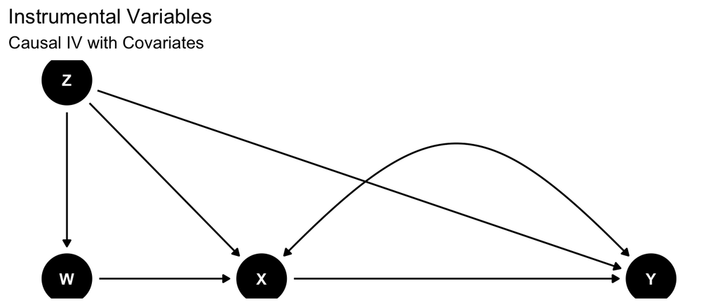

```r
ivzgraph<-dagitty("dag{Y<-X; X<-W; X<->Y; Y<-Z; X<-Z; W<-Z}") #create graph
#Set position of nodes
  coords<-list(x=c(X = 0, Z = -1, Y = 2, W=-1),y=c(X = 0, Z = 0.5, Y = 0, W=0))
  coords_df<-coords2df(coords)
  coordinates(ivzgraph)<-coords2list(coords_df)
ggdag(ivzgraph)+theme_dag_blank()+ggplot2::labs(title="Instrumental Variables",subtitle="Causal IV with Covariates") #Plot causal graph
```

- Often only have conditionally randomly assigned instrument, or think conditions more plausible given controls
  - E.g., monotonicity within narrow classes of medical cases/defendants only
- If we make all LATE assumptions conditional on covariates $Z$, conditional Wald identifies conditional LATE
  - $\beta(z):=E[Y_i^1-Y_i^0|X_i^1=1,X_i^0=0,Z_i=z]=\frac{E[Y_i|W_i=1,Z_i=z]-E[Y_i|W_i=0,Z_i=z]}{E[X_i|W_i=1,Z_i=z]-E[X_i|W_i=0,Z_i=z]}$
- Under a positivity condition $0<P(W=1|Z=z)<1$ the unconditional LATE is identified as (Frölich (2007) Theorem 1)
  - $E[Y_i^1-Y_i^0|X_i^1=1,X_i^0=0]=\frac{\int (E[Y_i|W_i=1,Z_i=z]-E[Y_i|W_i=0,Z_i=z])f(z)dz}{\int (E[X_i|W_i=1,Z_i=z]-E[X_i|W_i=0,Z_i=z])f(z) dz}$
- **Proof:**
- $LATE=\int\beta(z)f(z|X^1=1,X^0=0)dz$ L.I.E.
- $=\int\beta(z)\frac{P(X^1=1,X^0=0|Z=z)f(z)}{P(X^1=1,X^0=0)}dz$ Bayes Rule
- $=\int\beta(z)\frac{(E[X_i|W_i=1,Z_i=z]-E[X_i|W_i=0,Z_i=z])f(z)}{\int(E[X_i|W_i=1,Z_i=z]-E[X_i|W_i=0,Z_i=z])f(z)dz}dz$ conditional compliers identified by first stage
- $=\frac{\int (E[Y_i|W_i=1,Z_i=z]-E[Y_i|W_i=0,Z_i=z])f(z)dz}{\int (E[X_i|W_i=1,Z_i=z]-E[X_i|W_i=0,Z_i=z])f(z) dz}$ conditional Wald identifies $\beta(z)$

## Estimating (Conditional) LATE

- In binary case, convenience of LATE theorem is that it justified linear IV even with heterogeneous effects of treatment and of instrument
  - Albeit with an estimand that differs from the homogeneous effect people thought they were estimating
- Even outside of this case most common estimator is still Two Stage Least Squares 2SLS
  - Linear homogeneous model $Y=\beta_0+\beta_1X +Z^\prime\beta_2+U$ with endogeneity
  - Estimate first stage $X=\delta_0+\rho W + Z'\delta_2+E$ by OLS, get predicted $\widehat{X}$
  - Estimate second stage $Y=\beta_0+\beta_1\widehat{X} +Z^\prime\beta_2+U$ by OLS
- 2SLS is numerically equivalent to estimating conditional LATE formula with linear and additively separable effect of $Z$ in reduced form and first stage
  - Assumes heterogeneity in effects does not vary with $Z$
- To avoid these assumptions, use nonparametric estimators of $E[Y|W,Z]$, $E[X|W,Z]$
- Plug-in has usual slow rate properties, so may prefer to use robust semiparametric estimator

## Abadie’s kappa

- Like adjustment formula, can estimate LATE using conditional means or (inverse) propensity-score-like component or both
- Abadie (2003) derived weighting functions which re-weights conditional density to that of complier population
- Let $\pi(z)=P(W=1|Z=z)$, then $\frac{W}{\pi(Z)}$ is propensity weight for population with $W=1$, $\frac{1-W}{1-\pi(Z)}$ is weight for population with $W=0$, and $\frac{W}{\pi(Z)}-\frac{1-W}{1-\pi(Z)}$ reweights to difference in mean between $W=1$ and $W=0$ populations
- Abadie (2003) Theorem 3.1: Assume conditions of LATE theorem. Define the weights
  - $\kappa_0(W,Z,X)= -(1-X)(\frac{W}{\pi(Z)}-\frac{1-W}{1-\pi(Z)})$
  - $\kappa_1(W,Z,X)= X(\frac{W}{\pi(Z)}-\frac{1-W}{1-\pi(Z)})$
  - $\kappa(W,Z,X)= (1-\pi(Z))\kappa_0(W,Z,X)+\pi(Z)\kappa_1(W,Z,X)$
- Then $E[\kappa_0(W,Z)g(Y,Z)]/P(W^1=1,W^0=0)=E[g(Y^0,Z)|W^1=1,W^0=0]$,
  - $E[\kappa_1(W,Z)g(Y,Z)]/P(W^1=1,W^0=0)=E[g(Y^1,Z)|W^1=1,W^0=0]$, and
  - $E[\kappa(W,Z)g(Y,W,Z)]/P(W^1=1,W^0=0)=E[g(Y,W,Z)|W^1=1,W^0=0]$
- These can be estimated by conditional probability estimators (eg logit or ML method), provide alternative to linear mean modeling of 2SLS
- Moreover, $\kappa$ allows us to know features of covariate distribution for complier population
  - Can report table of average complier characteristics and compare with those for other groups, such as treated, untreated, and full sample
- As with other IPW-type estimates, sensitive to weak overlap

## Semiparametric Estimate

- With a Neyman orthogonal moment condition for conditional IV, can use ML estimators to avoid functional form assumptions
- Singh and Sun (2021) derive the conditions
  - Let $\mu(w,z)=E[XY|W=w,Z=z]$, $p(w,z)=E[X|W=w,Z=z]$, and $\pi(z)=P(W=1|Z=z)$ be nuisance parameters and $\theta^1=E[Y^1|W^1=1,W^0=0]$ be target functional
  - $\psi^1(Y,X,Z,W,\theta^1,\eta)=\mu(1,z)-\mu(0,Z)-\theta^1(p(1,Z)-p(0,Z))+(\frac{W}{\pi(Z)}-\frac{1-W}{1-\pi(Z)})[XY-\mu(W,Z)-\theta^1(X-p(W,Z))]$ is an orthogonal moment identifying target
- Formula for $\theta^0=E[Y^0|W^1=1,W^0=0]$ is related, except replace $\mu(w,z)=E[(X-1)Y|W=w,Z=z]$, $p(w,z)=E[X-1|W=w,Z=z]$
  - $\psi^0(Y,X,Z,W,\theta^0,\eta)=\mu(1,z)-\mu(0,Z)-\theta^0(p(1,Z)-p(0,Z))+(\frac{W}{\pi(Z)}-\frac{1-W}{1-\pi(Z)})[(X-1)Y-\mu(W,Z)-\theta^0(X-1-p(W,Z))]$
- With sample splitting, you can use any sufficiently fast estimates $\widehat{\eta}$ for nuisance parameters, solve $\frac{1}{L}\sum_{\ell=1}^{L}\frac{1}{n_\ell}\sum_{i\in\mathcal{I}^{(\ell)}}\psi^j(Y_i,X_i,Z_i,W_i,\hat{\theta}^j,\widehat{\eta}^{(-\ell)})=0$
- Singh and Sun (2021) also provide orthogonal moments for average complier characteristics, and propose estimators which target inverse propensities and so may be more stable with respect to overlap
- Kennedy, Balakrishnan, and G’Sell (2020) independently derive scores for LATE parameters, suggest classifiers for finding which units are compliers
- Earliest double robust LATE estimator may be Ogburn, Rotnitzky, and Robins (2015) ?

## Evaluating and Testing Model Conditions

- The IV model’s conditions are fairly restrictive, and should be evaluated for plausibility against what is known about the variables
- Your paper should explain the relevant background on data collection, experimental methods, and institutional and economic background for reader to understand how you justified use of the method
  - Rule of thumb: if paper’s main estimate relies on IV but reason for assuming exogeneity, or worse, even what the instrument is, not described in the abstract, that’s a red flag that instrument used is probably not great
- Always display first stage, reduced form, and IV estimate in tables to show components
- Beyond intuitive judgments, some of the conditions impose testable restrictions on the data
  - You absolutely should test these, and present the tests, any time you run IV
- For linear IV and 2SLS, there are classical “default” tests
- Sargan/Hansen J test: applicable only if model *overidentified*: has more instruments than endogenous treatments.
  - Works by comparing whether different instruments produce comparable IV estimates
  - Nominal justification is test of exogeneity, as it will reject if some instruments violate exclusion or exogeneity
  - With heterogeneous effects, rejection may instead be picking up that different IVs estimate different LATEs
  - If multiple IVs similar (eg same effect in different locations/times, etc), may all have similar biases and so fail to reject even if exogeneity false
  - Maybe best thought of as test of functional form restrictions in IV or GMM
- Durbin-Wu-Hausman test: comparison of IV/2SLS vs OLS estimates
  - If endogeneity or omitted variables not a problem in the first place, IV won’t be distinguishable from OLS
  - Good to know, but not a test of IV assumptions, and definitely not license to use use OLS if it can’t reject
  - Power often low because failure of relevance biases IV in direction of OLS
- First stage F-statistic: tests relevance condition
  - Folk wisdom, loosely supported by simulation evidence in Stock and Yogo (2005), is that F>10 suggests bias is small
  - Rule derived in linear Gaussian homoskedastic setting with 1 IV and no controls, and even then may not be right choice

## Relevance and Handling Weak IVs

- When IV relevance condition even close to failing, Gaussian limit theory is bad guide to finite sample properties
  - Even if not weak, ratio estimators tend to be very heavy-tailed due to chance of dividing by near 0
- Without *strict* relevance, there may be no confidence interval with finite expected width that provides valid coverage for IV estimate
- Limit theory localizing first stage effect near 0 shows asymptotic distribution biased towards OLS estimate
- With many IVs in 2SLS, problem gets more severe
- Showing pretests for weak IV is fine as matter of transparency, less so for decision-making
  - Should use tests robust to heteroskedasticity, clustering etc
  - Critical values have been derived beyond which IV is “safe”, for various conflicting definitions of safe
  - Pre-testing distorts inference on actual effects, and leads to undesirable and hard to correct biases if not accounted for
- If concerned about weakness, better to directly use inference procedure robust to it: Andrews, Stock, and Sun (2019) survey options
- Simple one: if reduced form effect is 0, IV estimate of effect must also be 0
  - No info on first stage used at all, so test distribution normal no matter how weak (Chernozhukov and Hansen (2008))
- Anderson-Rubin: use $\chi^2$ test of $H_0: \widehat{\rho}-\widehat{\gamma}\beta_0=0$, report all $\beta_0$ that don’t reject as confidence interval
  - Produces CI, not point estimate, which is provably best you can do in local-to-0 case
  - Other tests (K-test, CLR, etc) operate on same principle, may sometimes have better power
- If mildly weak, sometimes penalized versions of IV show reduced bias

## Interpretation: What is a LATE and why should we care?

- LATE result has been criticized because it is a causal effect for a subpopulation defined in terms of counterfactuals
  - We do not observe who is a complier, and can’t design a policy which targets only them
- If instrument is actual thing we control (prescribe the pill, not take the pill), maybe just want ITT
- With homogeneous effects, results can be extrapolated, but then don’t need to rely on heterogeneous effects framework
- Case becomes stronger for use if we consider conditioning
  - Abadie’s $\kappa$ lets us know at least properties of who IV affects
  - Conditional IV lets us know how effect varies with attributes
- If target policy is to treat everyone, really do just want ATE
  - Can show it’s not identified in general under these assumptions
- If Y bounded in $[0,1]$ (w.l.o.g.), under IV assumptions can identify bounds on ATE that are often fairly narrow
  - Balke and Pearl (1997) give system of inequalities, Kennedy, Balakrishnan, and G’Sell (2020) add conditioning on covariates
  - Idea is to replace $Y$ by bounds for those subsets where value is unknown, and observed values where it is
  - Joint probabilities of $Y,X,W$ restrict possibilities and so conditioning yields tighter bounds than in in unconditional case
  - Bounds smaller as fraction of compliers grows: extrapolating to fewer units

## What to do about implausible or invalid IV

- Without monotonicity, may retreat to using applicable subsets of Balke and Pearl (1997) inequalities
- When random assignment or exclusion implausible but only slightly so, may do sensitivity analysis (eg Conley, Hansen, and Rossi (2012))
  - Assume fixed nonzero degree of correlation of instrument with error or direct effect, construct CI over all plausible values
  - Bayesian prior natural here, though need additional modeling assumptions for Bayesian IV
- Weak instruments make exclusion or exogeneity violations worse, since error is scaled by inverse of first stage
- Systematic reviews of of IV applications (Lal et al. (2021), Young (2021)) find preponderance of implausibly large effects, in addition to frequent violations of IV assumptions
- Often find IV larger than OLS estimate, even when intuition for source of endogeneity bias would suggest OLS biased up
  - Exactly what you would expect if exogeneity condition violated and instrument slightly weak
  - Also results from high sensitivity to outliers: Fisher randomization tests or HC3 robust SEs may help correct inference
- Classic excuse: “measurement error in X”: biases OLS toward 0, fixed by valid/relevant IV
- Tolerable excuse: LATE measures effect for subpopulation which stronger effects
  - If you are going to argue this, should support with measures of complier characteristics that might suggest this is true
  - Actually reasonable in many educational applications, which target marginal students for whom remedial education appears highly effective

## Extensions: Multi-valued Instrument

- If $W$ takes more than 2 values, can take any 2, and, if LATE assumptions hold pairwise obtain effect for compliers of that particular change
- Imbens and Angrist (1994) show that under LATE conditions 2SLS gives positively weighted average of LATEs for pairs of IVs
  - Says we get sign right if all effects the right direction, and get value right if all effects the same, but otherwise not clear why we would care about that particular weighted average
  - Justification of old methods by showing they don’t break too badly is somewhat helpful
  - Best face on it: researchers are going to summarize effect by a number anyway, and will think of effects as homogeneous, so want to use “simple” method based on homogeneity, then if it’s not true fall back to weighted average interpretation
  - Goes awry when weighting function choice has strong effect on results
- LATE Model can be shown to be exactly equivalent to one with random utility discrete choice model of treatment decision
  - $X=1\{\pi(W)\geq V\}$, $V|W\sim U[0,1]$ w.l.o.g., so $\pi(w)=P(X=1|W=w)$ is propensity, $Y^1=\mu_1+U_1$, $Y^0=\mu_0+U_0$, $(V,U_1,U_0)\perp W$
- For continuous, ordered $W$, we can compare take points where propensity adjacent and arbitrarily close to measure “Local IV” near $\pi(w)=p$ by LATE result
  - $\tau_{LIV}(p)=\underset{h\to0}{\lim}\frac{E[Y_i|\pi(W_i)=p+h]-E[Y_i|\pi(W_i)=p-h]}{E[X_i|\pi(W_i)=p+h]-E[X_i|\pi(W_i)=p-h]}=\underset{h\to0}{\lim}E[Y_i^1-Y_i^0|p-h<V\leq p+h]=\frac{\partial}{\partial p}E[Y_i|V=p]$
- Causal effect for subpopulation induced into treatment by marginal change in instrument: hence “Marginal Treatment Effect” Curve
- Can use curve to identify effects for subpopulations induced into treatment by different policies, which may, e.g., offer varying levels of incentives to take treatment
- Can estimate nonparametrically, or impose a parametric model. Can also condition curve on covariates $Z$. Cornelissen et al. (2016) surveys methods

## Extensions: Continuous Treatment

- As with adjustment, need either functional form restrictions or smoothing to get effects of a continuous treatment with IV
- In linear homogeneous case, 2SLS extends naturally, and is most used method
- Allowing effect of controls to be nonlinear, but treatment linear and additively separable, gives a partially linear IV model, estimable by semiparametric methods
- Parametric nonlinearities in IV give you GMM. Allowing the first stage to be arbitrarily related gives conditional GMM
  - Efficient choice of instruments based on conditional expectation functions given IV, can be estimated nonparametrically
- Nonparametric nonlinearities in IV create massive estimation issues.
- NPIV model (Newey and Powell (2003), Ai and Chen (2003)) $E[Y-\mu(X)|W]=0$ with continuous $X,W$
  - Can estimate by regularized 2SLS under stronger version of relevance condition called “completeness”
  - Obtains “ill-posed” slower than usual nonparametric rates, effectively because with continuum of instruments, parts of instrument set are necessarily weak
  - Summaries of the effect, like average derivatives or projections, can still be semiparametrically efficient
- That still assumes additively separable errors: relax by (nonparametric) quantile IV or other extensions

## Software

- Classic IV in `AER`
- Weak IV robust inference in `ivmodel`
- Semiparametric LATE or bounds on ATE in `npcausal`
- Nonparametric IV (additive or partially linear), with kernels in `np`
- Lasso IV in `hdm`, DoubleML partially linear IV or semiparametric LATE in `DoubleML`
- Various tests and extensions mainly in Stata

## Example: Survey Experiment

- Mullainathan, Washington, and Azari (2009) study effect of watching 2005 NYC mayoral debate on candidate evaluation
- Survey before debate, and choose at random recommendation to watch debate or watch placebo show
- Use suggestion $W=watch$ as IV for treatment $X=actwatch$ actually watching, with outcome $Y=bloomscore$ candidate score
- Randomness by design, monotonicity if suggestions don’t create aversion to watching, exclusion if suggestion alone doesn’t impact candidate views
- Table contains (1) Wald IV (=LATE under LATE theorem), (2) OLS estimate, (3) First Stage (4) Reduced Form

```r
#Load the data set from your directory
#In my case this is saved at
debate<-read.dta("Data/M_Washington_A_Chapter_2010_Dataset.dta")

#Assemble indicator for watched or didn't
debate$actwatch<-(debate$watchdps1=="yes"|debate$watchdps2=="yes")
debate$actwatch[is.na(debate$actwatch)]<-FALSE
debate$actwatch<-as.numeric(debate$actwatch)

#Alternately, use
debate$actwatch<-as.numeric(debate$watchdps)-1

ols<-lm(formula=bloomsc~actwatch,data=debate)
ols.results<-coeftest(ols,vcov=vcovHC(ols,type="HC3"))

reducedform<-lm(bloomsc~watch,data=debate)
reducedform.results<-coeftest(reducedform,vcov=vcovHC(reducedform,type="HC3"))

firststage<-lm(actwatch~watch,data=debate)
firststage.results<-coeftest(firststage,vcov=vcovHC(firststage,type="HC3"))

ivwatch<-ivreg(formula=bloomsc~actwatch|watch,data=debate)
ivwatch.results<-coeftest(ivwatch,vcov=vcovHC(ivwatch,type="HC3"))
```

```r
stargazer(ivwatch.results,ols.results,firststage.results,reducedform.results,header=FALSE,
    type="html",
    omit.stat=c("adj.rsq"),
    font.size="tiny",
    title="Wald Estimate of Debate Watching on Candidate Score")
```

**Wald Estimate of Debate Watching on Candidate Score**

|  | *Dependent variable:* |  |  |  |
| --- | --- | --- | --- | --- |
|  | (1) | (2) | (3) | (4) |
| actwatch | 5.775 | -3.134 |  |  |
|  | (8.192) | (2.035) |  |  |
| watch |  |  | 0.205*** | 1.234 |
|  |  |  | (0.027) | (1.733) |
| Constant | 67.665*** | 70.111*** | 0.162*** | 68.631*** |
|  | (2.409) | (0.985) | (0.017) | (1.229) |
| *Note:* | p<0.1; p<0.05; p<0.01 |  |  |  |

## Conditional IV

```r
mydata<-data.frame(y=debate$bloomsc,a=debate$actwatch,z=debate$watch,x1=debate$female,x2=debate$black,x3=debate$white,x4=debate$age)
mydata<-na.omit(mydata)
x=as.matrix(mydata[,4:7])
set.seed(101)
boundsresults<-ivbds(y=mydata$y/100,a=mydata$a,z=mydata$z,x=x,nsplits=5,sl.lib=c("SL.glm","SL.ranger"))
```

```
##   |                                                                              |                                                                      |   0%  |                                                                              |====                                                     …
##   parameter          lb         ub      ci.ll     ci.ul
## 1       ATE -0.48626192 0.29688835 -0.5230338 0.3310284
## 2 beta(h_q) -0.52000608 0.27717903 -0.6920250 0.3925359
## 3      LATE  0.02781938 0.02781938 -0.1394741 0.1951129
```

```r
lateresults<-ivlate(y=mydata$y,a=mydata$a,z=mydata$z,x=x,nsplits=5,sl.lib=c("SL.glm","SL.ranger"))
```

```
##   |                                                                              |                                                                      |   0%  |                                                                              |====                                                     …
##   parameter       est         se         ci.ll      ci.ul  pval
## 1      LATE 2.9067270 8.60270865 -1.395458e+01 19.7680359 0.735
## 2  Strength 0.2132277 0.03017744  1.540799e-01  0.2723755    NA
## 3 Sharpness 0.0010000 0.07662264  5.159907e-69  1.0000000    NA
```

- Compare 2SLS, assuming linearity and homogeneity

```r
tslswatch<-ivreg(formula=bloomsc~actwatch+female+black+white+age|watch+female+black+white+age,data=debate)
(tslswatch.results<-coeftest(tslswatch,vcov=vcovHC(tslswatch,type="HC3")))
```

```
##
## t test of coefficients:
##
##              Estimate Std. Error t value  Pr(>|t|)
## (Intercept) 59.013126   5.025551 11.7426 < 2.2e-16 ***
## actwatch     3.534963   8.631364  0.4095  0.682240
## female      -0.910754   1.841352 -0.4946  0.621002
## black       -6.408480   4.122680 -1.5544  0.120450
## white        1.990523   3.679699  0.5409  0.588686
## age          0.153922   0.055601  2.7684  0.005756 **
## ---
## Signif. codes:  0 '***' 0.001 '**' 0.01 '*' 0.05 '.' 0.1 ' ' 1
```

- In this case, results are very similar, within range of sampling error

## Summary

- Classical IV estimates treatment even with confounding under exogeneity and relevance
  - Derived assuming linear homogenous effects
- Allowing heterogeneity requires thinking through subpopulations involved in each
- Under exclusion, relevance, random assignment and monotonicity, binary IV estimates Local Average Treatment Effect
  - Efficiently estimable also conditional on covariates
- Can and should justify, test, and report on these conditions when using IV
  - Formal tests exist for many of them
- Realistically IV most likely justifiable in experimental settings with some noncompliance
  - But be on the lookout for natural experiments where (conditionally) random forces impact a treatment but not directly the outcome

## References

Abadie, Alberto. 2003. “Semiparametric Instrumental Variable Estimation of Treatment Response Models.” *Journal of Econometrics* 113 (2): 231–63.

Ai, Chunrong, and Xiaohong Chen. 2003. “Efficient Estimation of Models with Conditional Moment Restrictions Containing Unknown Functions.” *Econometrica* 71 (6): 1795–1843.

Andrews, Isaiah, James H Stock, and Liyang Sun. 2019. “Weak Instruments in Instrumental Variables Regression: Theory and Practice.” *Annual Review of Economics* 11: 727–53.

Balke, Alexander, and Judea Pearl. 1997. “Bounds on Treatment Effects from Studies with Imperfect Compliance.” *Journal of the American Statistical Association* 92 (439): 1171–76.

Chernozhukov, Victor, and Christian Hansen. 2008. “The Reduced Form: A Simple Approach to Inference with Weak Instruments.” *Economics Letters* 100 (1): 68–71.

Conley, Timothy G, Christian B Hansen, and Peter E Rossi. 2012. “Plausibly Exogenous.” *Review of Economics and Statistics* 94 (1): 260–72.

Cornelissen, Thomas, Christian Dustmann, Anna Raute, and Uta SchÃ¶nberg. 2016. “From LATE to MTE: Alternative Methods for the Evaluation of Policy Interventions.” *Labour Economics* 41: 47–60. https://doi.org/https://doi.org/10.1016/j.labeco.2016.06.004.

Frölich, Markus. 2007. “Nonparametric IV Estimation of Local Average Treatment Effects with Covariates.” *Journal of Econometrics* 139 (1): 35–75.

Imbens, Guido W, and Joshua D Angrist. 1994. “Identification and Estimation of Local Average Treatment Effects.” *Econometrica* 62 (2): 467–75.

Kennedy, Edward H, Sivaraman Balakrishnan, and Max G’Sell. 2020. “Sharp Instruments for Classifying Compliers and Generalizing Causal Effects.” *The Annals of Statistics* 48 (4): 2008–30.

Kitagawa, Toru. 2015. “A Test for Instrument Validity.” *Econometrica* 83 (5): 2043–63.

Lal, Apoorva, Mackenzie William Lockhart, Yiqing Xu, and Ziwen Zu. 2021. “How Much Should We Trust Instrumental Variable Estimates in Political Science? Practical Advice Based on over 60 Replicated Studies.” https://papers.ssrn.com/sol3/papers.cfm?abstract_id=3905329.

Mourifié, Ismael, and Yuanyuan Wan. 2017. “Testing Local Average Treatment Effect Assumptions.” *Review of Economics and Statistics* 99 (2): 305–13.

Mullainathan, Sendhil, Ebonya Washington, and Julia R Azari. 2009. “The Impact of Electoral Debate on Public Opinions: An Experimental Investigation of the 2005 New York City Mayoral Election.” *Political Representation*, 324–41.

Newey, Whitney K, and James L Powell. 2003. “Instrumental Variable Estimation of Nonparametric Models.” *Econometrica* 71 (5): 1565–78.

Ogburn, Elizabeth L, Andrea Rotnitzky, and James M Robins. 2015. “Doubly Robust Estimation of the Local Average Treatment Effect Curve.” *Journal of the Royal Statistical Society: Series B (Statistical Methodology)* 77 (2): 373–96.

Singh, Rahul, and Liyang Sun. 2021. “Automatic Kappa Weighting for Instrumental Variable Models of Complier Treatment Effects.” https://arxiv.org/abs/1909.05244.

Stock, James H, and Motohiro Yogo. 2005. “Testing for Weak Instruments in Linear Iv Regression.” In *Identification and Inference for Econometric Models: Essays in Honor of Thomas Rothenberg*, 80–108. Cambridge University Press.

Sun, Zhenting. 2021. “Instrument Validity for Heterogeneous Causal Effects.” https://arxiv.org/abs/2009.01995.

Wright, Philip G. 1928. *Tariff on Animal and Vegetable Oils*. Macmillan Company, New York.

Young, Alwyn. 2021. “Leverage, Heteroskedasticity and Instrumental Variables in Practical Application.” https://personal.lse.ac.uk/YoungA/LeverageandIV.pdf.